# Exemplos de uso

### RNN - Implementação e treinamento

A fim de entender o funcionamento das Rendes Neurais Recorrentes, vamos pegar o exemplo apresentado por Vasilev et al. (2019), que é contar a quantidade de vezes que o número 1 aparece em uma sequência de valores binários. É um exemplo de RNN “Muitos para Um”.

A implementação será feita utilizando Python e NumPy, não será necessária a importação de bibliotecas de Deep Learning, visto que é um exemplo simples.

Veja a sequência de entrada e a correspondente saída:

**In**: (0, 0, 0, 0, 1, 0, 1, 0, 1, 0)

**Out**: 3

Essa rede terá apenas dois parâmetros, um peso de entrada U e um peso recorrente W. O peso de saída V será configurado como 1, para que a saída y seja o último estado.

Inicialmente, vamos importar o numpy e definir o conjunto de dados de treinamento x e o conjunto de rótulos y. x é bidimensional, visto que a primeira dimensão representa cada subconjunto da amostra.

Como nosso conjunto de dados é pequeno, não há necessidade de fazer a divisão em subconjuntos menores:

*Importando biblioteca NumPy e definindo array*

```python
import numpy as np

# A primeira dimensão representa o subconjunto
x = np.array([[0, 0, 0, 0, 1, 0, 1, 0, 1, 0]])

y = np.array([3])
```

A relação de recorrência desta rede é um modelo linear definido por

st = st-1 *W + xt* U

que pode ser implementada como:

*Função da relação de recorrência*

```python
def step(s, x, U, W):
    return x * U + s * W
```

Os valores de estado, st, e pesos, W e U, são valores escalares simples, neste caso, basta somar as entradas no decorrer da sequência.

Então, se definirmos U = 1, receberemos o valor total de cada entrada. Se definirmos W = 1, os valores acumulados não decairão.

Sendo assim, para este exemplo, conseguiremos a saída 3, que é a desejada.

O passo adiante (forward pass) desdobra a RNN ao longo da sequência e constrói uma pilha de estados a cada interação.

A seguir, veja a implementação do forward pass, que retornará a ativação s para cada interação recorrente e cada valor do conjunto:

*Definindo função de forward*

```python
def forward(x, U, W):
    # Número de amostras do subconjunto
    number_of_samples = len(x)

    # Tamanho de cada amostra
    sequence_length = len(x[0])

    # Inicialize o estado de ativação para cada amostra da sequência
    s = np.zeros((number_of_samples, sequence_length + 1))

    # Atualize os estados no decorrer da sequencia
    for t in range(0, sequence_length):
        # step Function
        s[:, t + 1] = step(s[:, t], x[:, t], U, W)

    return s
```

Após definir o passo adiante e a função de custo, é possível definir, também, o gradiente de propagação de volta (backward) utilizando backpropagation.

Como os pesos W e U são constantes em todas as camadas, acumularemos o erro derivado de cada interação recorrente e, ao final, atualizaremos os pesos com o valor acumulado. É necessário obter o gradiente da saída com relação à função de custo, e então, propagá-lo pela pilha de atividades realizadas durante os passos adiante.

Os passos para trás retiram as atividades da pilha para acumular seus erros derivados a cada interação.

A seguir, veja a implementação do backward pass:

*Definindo função de backward*

```python
def backward(x, s, y, W):
    sequence_length = len(x[0])

    # A saída da rede é apenas a última ativação da sequência
    s_t = s[:, -1]

    # Calcule o gradiente de saída w.r.t. Função de custo
    # MSE do estado final.
    gS = 2 * (s_t - y)

    # Defina as acumulações gradientes em 0
    gU, gW = 0, 0

    # Retroceda acumulando os gradientes
    for k in range(sequence_length, 0, -1):
        # Calcule os gradientes dos parâmetros e acumule os
        # resultados
        gU += np.sum(gS * x[:, k - 1])
        gW += np.sum(gS * s[:, k - 1])

        # Calcule o gradiente de saída para a camada anterior
        gS = gS * W

    return gU, gW
```

A partir de agora, é possível utilizar o Gradiente Descendente para otimizar a rede.

Vamos utilizar o erro q uadrático médio:

*Função de treinamento*

```python
def train(x, y, epochs, learning_rate=0.0005):
    """Train the network"""
    # Defina os parâmetros iniciais
    weights = (-2, 0) # (U, W)

    # Acumule as perdas e seus respectivos pesos
    losses = list()
    weights_u = list()
    weights_w = list()

    # Execute o gradiente descendente interativo
    for i in range(epochs):
        # Execute os passos adiante e para trás para oobter
        # os gradientes
        s = forward(x, weights[0], weights[1])

        # Calcule a função de custo MSE
        loss = (y[0] - s[-1, -1]) ** 2

        # Armazene os valores de perda e pesos para mostrar depois
        losses.append(loss)

        weights_u.append(weights[0])
        weights_w.append(weights[1])

        gradients = backward(x, s, y, weights[1])
        # Atualize cada parâmetro 'p' para p = p-(gradiente * taxa_aprendizado)
        # 'gp' é o gradiende do parâmetro 'p'
        weights = tuple((p - gp * learning_rate) for p, gp in zip(weights, gradients))

    return np.array(losses), np.array(weights_u), np.array(weights_w)
```

Em seguida, implementaremos a função plot_training, que exibe os pesos e perda:

*Plotando treinamento*

```python
def plot_training(losses, weights_u, weights_w, bottom, top):
    import matplotlib.pyplot as plt

    # Remove os valores nan e inf
    losses = losses[~np.isnan(losses)][:-1]
    weights_u = weights_u[~np.isnan(weights_u)][:-1]
    weights_w = weights_w[~np.isnan(weights_w)][:-1]

    # Mostra os pesos U e W
    fig, ax1 = plt.subplots(figsize=(5, 3.4))

    ax1.set_ylim(-3, 2)
    ax1.set_xlabel('Ciclos')
    ax1.plot(weights_w, label='W', color='red', linestyle='--')
    ax1.plot(weights_u, label='U', color='blue', linestyle=':')
    ax1.legend(loc='upper left')

    # Instancia um novo eixo que compartilha o mesmo eixo x
    # Mostra a perda no Segundo eixo
    ax2 = ax1.twinx()

    # Retire os comentários para mostrar os gradientes
    ax2.set_ylim(bottom, top)
    ax2.plot(losses, label='Loss', color='green')
    ax2.tick_params(axis='y', labelcolor='green')
    ax2.legend(loc='upper right')

    fig.tight_layout()

    plt.show()
```

*Treinando*

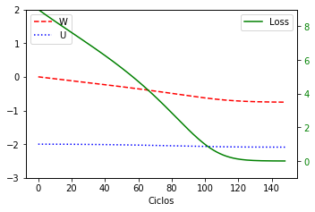

```python
losses, weights_u, weights_w = train(x, y, epochs=150)
plot_training(losses, weights_u, weights_w, -1, 9)
```

*Problema da dissipação e explosão dos gradientes*

O problema da dissipação ou explosão dos gradientes acontece quando os gradientes se tornam grandes ou pequenos demais, dificultando uma dependência de longo alcance (com 10 interações ou mais) na estrutura do conjunto de dados de entrada.

Para visualizar o problema, vamos utilizar uma sequência de treinamento um pouco mais longa:

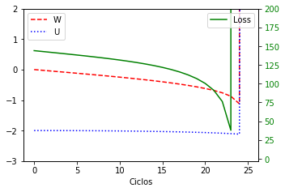

```python
x = np.array([[0, 0, 0, 0, 1, 0, 1, 0, 1, 0, 0, 0, 0, 0, 1, 0, 1, 0, 1, 0, 0, 0, 0, 0, 1, 0, 1, 0, 1, 0, 0, 0, 0, 0, 1, 0, 1, 0, 1, 0]])

y = np.array([12])

losses, weights_u, weights_w = train(x, y, epochs=150)

plot_training(losses, weights_u, weights_w, -3, 200)
```

No gráfico é possível perceber que os pesos se aproximam do ótimo e o custo cai até que eles dão um salto. Esse fenômeno é conhecido como explosão do gradiente.

A dissipação do gradiente é o fenômeno inverso, onde os valores decaem exponencialmente.

Em ambos os casos, a rede neural recursiva perderá a capacidade de aprender as dependências da sequência a longo prazo.

A melhor forma de resolver este problema é utilizando o LSTM (Long Short-Term Memory), que é uma rede neural recorrente modificada com suporte a DL4J.